# Beta and Stock Returns - A Portfolio Analysis

Digital Tools For Finance

Kun Zhang, Ziyun Ni, Ruixuan Zhou, Kevin Hardegger

University of Zurich - Fall 2020

For our final project in **Digital Tools for Finance** we analyse beta and stock returns of Swiss stocks titles that have been included in the Swiss Market Index (SMI) since its inception in June 1988. The goal of this analysis is to analyse how accurate the Capital Asset Pricing Model (CAPM) can be applied to the Swiss Stock Market, and if its derived principles hold truth.

### 1. Loading Data

We collected the needed data from Datastream and saved them as CSV files. As our next step, we established a database on MySQL called DT4F and inserted the CSV files. By this, we can access the data via SQL queries and have no need for the CSV files anymore. While this step isn’t necessary, we decided to adopt it nevertheless, as we wanted to test the combination between R with SQL and get a first personal glance of how MySQL works.

We include both methods for loading the data with SQL and CSV files. Thus, the viewer can choose which method he prefers. Both the SQL and csv files can be found in the github repository and the viewer should not forget to adapt the login details for MySQL.

#### 1.1 Loading with SQL

We start with connecting to the MySQL database. (Adapt login details) Below we see the available tables of our database.

```
## [1] "smimonthly"        "stockdailybetas"   "stockdailyprices"
## [4] "swissbondsmonthly"
```

Next, we access the data via SQL queries, create and modify the data frames which we need for our further calculations.

```r
# Loading via SQL

# Load prices table via SQL query
prices = dbGetQuery(mydb, "SELECT * FROM stockdailyprices")
# convert columns to numeric
columns <-c(2:61)
prices[, columns] <- lapply(columns, function(x) as.numeric(prices[[x]]))
# modify returns df
date <- as.Date(prices[,1],format="%d.%m.%Y")
prices.ts <- xts(x = prices[,-1], order.by = date)
returns <- Return.calculate(prices = prices.ts, method = 'discrete')

# Load beta table via SQL query
Daily_betas = dbGetQuery(mydb, "SELECT * FROM stockdailybetas")
# convert columns to numeric
Daily_betas[, columns] <- lapply(columns, function(x) as.numeric(Daily_betas[[x]]))
# modify beta df
date_betas <- as.Date(Daily_betas[,1],format="%d.%m.%Y")
Daily_betas <- xts(x = Daily_betas[,-1], order.by = date_betas)
Daily_betas.ts <- as.matrix(Daily_betas['1994-04-29/2017-12-28'])
Daily_Returns <- as.matrix(returns['1994-04-30/2017-12-29'])

# Load Swiss Bonds table via SQL query
swissbond_monthly = dbGetQuery(mydb, "SELECT * FROM swissbondsmonthly")
# convert columns to numeric
colbond <-c(2:14)
swissbond_monthly[, colbond] <- lapply(colbond, function(x) as.numeric(swissbond_monthly[[x]]))
# modify Swiss bond df
datebond_monthly <- as.Date(swissbond_monthly$Date,format="%d.%m.%Y")
swissbond_monthly <- xts(swissbond_monthly[,-1], order.by = datebond_monthly)
swissbond_monthly <- swissbond_monthly/100
swissbond_monthly <- (1+swissbond_monthly)^(1/12)-1

# Load SMI table via SQL query
SMI_monthly  = dbGetQuery(mydb, "SELECT * FROM smimonthly")
# convert columns to numeric
colsmi <-c(2:3)
SMI_monthly[, colsmi] <- lapply(colsmi, function(x) as.numeric(SMI_monthly[[x]]))
# modify SMI df
dateSMI_monthly <- as.Date(SMI_monthly$Date,format="%d.%m.%Y")
SMI_monthly <- xts(SMI_monthly[,-1], order.by = dateSMI_monthly)
```

#### 1.2 Loading with CSV

Here is the code for loading tables as CSV files as an alternative to the SQL connection.

```r
# Loading via CSV files

# Read daily stock prices and create returns df
prices <- read.table("StockPricesDaily.csv",sep = ";", header = TRUE, na = "NA")
date <- as.Date(prices[,1],format="%d.%m.%Y")
prices.ts <- xts(x = prices[,-1], order.by = date)
returns <- Return.calculate(prices = prices.ts, method = 'discrete')

# Read daily betas and create beta df
Daily_betas <- read.table("Stock_betas_daily.csv",sep = ";", header = TRUE, na = "NA")
date_betas <- as.Date(Daily_betas[,1],format="%d.%m.%Y")
Daily_betas <- xts(x = Daily_betas[,-1], order.by = date_betas)
Daily_betas.ts <- as.matrix(Daily_betas['1994-04-29/2017-12-28'])
Daily_Returns <- as.matrix(returns['1994-04-30/2017-12-29'])

# Read monthly swissbond data and create df
swissbond_monthly <- read.csv("Swissbond_monthly.csv",sep = ";", header = TRUE, dec = '.')
datebond_monthly <- as.Date(swissbond_monthly$Date,format="%d.%m.%Y")
swissbond_monthly <- xts(swissbond_monthly[,-1], order.by = datebond_monthly)
swissbond_monthly <- swissbond_monthly/100
swissbond_monthly <- (1+swissbond_monthly)^(1/12)-1

# Read monthly SMI Total return data and create df
SMI_monthly <- read.table("SMIMonthly.csv",sep = ";", header = TRUE, na = "NA")
dateSMI_monthly <- as.Date(SMI_monthly$Date,format="%d.%m.%Y")
SMI_monthly <- xts(SMI_monthly[,-1], order.by = dateSMI_monthly)
```

### 2. Calculation and Portfolio Building

Having the tables successfully saved in data frames, we start with the calculation of the daily returns and daily betas. We want to construct 5 portfolios based on their daily beta values which are rebalanced on a daily basis. We calculate the betas, sort these in quintiles, and then build the portfolios in an ascending order. In other words, portfolio 1 will contain the stocks with the lowest daily betas, while portfolio 5 will contain the stocks with the highest beta.

```r
# create empty vectors with length = number of periods
P_Returns_P1_daily <- as.matrix(rep(NA,dim(Daily_betas.ts)[1]))
P_Returns_P2_daily <- as.matrix(rep(NA,dim(Daily_betas.ts)[1]))
P_Returns_P3_daily <- as.matrix(rep(NA,dim(Daily_betas.ts)[1]))
P_Returns_P4_daily <- as.matrix(rep(NA,dim(Daily_betas.ts)[1]))
P_Returns_P5_daily <- as.matrix(rep(NA,dim(Daily_betas.ts)[1]))

# create empty vectors with length = number of periods
P_beta_P1_daily <- as.matrix(rep(NA,dim(Daily_betas.ts)[1]))
P_beta_P2_daily <- as.matrix(rep(NA,dim(Daily_betas.ts)[1]))
P_beta_P3_daily <- as.matrix(rep(NA,dim(Daily_betas.ts)[1]))
P_beta_P4_daily <- as.matrix(rep(NA,dim(Daily_betas.ts)[1]))
P_beta_P5_daily <- as.matrix(rep(NA,dim(Daily_betas.ts)[1]))

# Calculating Returns
# use a for loop to go through each time period
for (j in 1:dim(Daily_betas.ts)[1])
{

  SUB_daily <- Daily_betas.ts[j,]

  # divide the stocks contained in SMI into 5 portfolios sorted on their betas
  P1_P_daily <- subset(SUB_daily,subset = SUB_daily < quantile(SUB_daily , c(0.2),na.rm=TRUE))
  P2_P_daily <- subset(SUB_daily,subset = SUB_daily < quantile(SUB_daily , c(0.4),na.rm=TRUE)& SUB_daily >= quantile(SUB_daily , c(0.2),na.rm=TRUE))
  P3_P_daily <- subset(SUB_daily,subset = SUB_daily < quantile(SUB_daily , c(0.6),na.rm=TRUE)& SUB_daily >= quantile(SUB_daily , c(0.4),na.rm=TRUE))
  P4_P_daily <- subset(SUB_daily,subset = SUB_daily < quantile(SUB_daily , c(0.8),na.rm=TRUE)& SUB_daily >= quantile(SUB_daily , c(0.6),na.rm=TRUE))
  P5_P_daily <- subset(SUB_daily,subset = SUB_daily >= quantile(SUB_daily, c(0.8),na.rm=TRUE))

  # calculate the returns of the portfolios of each beta ranked portfolios for every single period
  P_Returns_P1_daily[j] <- mean(Daily_Returns[j,names(P1_P_daily)],na.rm=TRUE)
  P_Returns_P2_daily[j] <- mean(Daily_Returns[j,names(P2_P_daily)],na.rm=TRUE)
  P_Returns_P3_daily[j] <- mean(Daily_Returns[j,names(P3_P_daily)],na.rm=TRUE)
  P_Returns_P4_daily[j] <- mean(Daily_Returns[j,names(P4_P_daily)],na.rm=TRUE)
  P_Returns_P5_daily[j] <- mean(Daily_Returns[j,names(P5_P_daily)],na.rm=TRUE)

   # calculate the daily betas of the portfolios of each beta ranked portfolios for every single period
  P_beta_P1_daily[j] <- mean(Daily_betas.ts[j,names(P1_P_daily)],na.rm=TRUE)
  P_beta_P2_daily[j] <- mean(Daily_betas.ts[j,names(P2_P_daily)],na.rm=TRUE)
  P_beta_P3_daily[j] <- mean(Daily_betas.ts[j,names(P3_P_daily)],na.rm=TRUE)
  P_beta_P4_daily[j] <- mean(Daily_betas.ts[j,names(P4_P_daily)],na.rm=TRUE)
  P_beta_P5_daily[j] <- mean(Daily_betas.ts[j,names(P5_P_daily)],na.rm=TRUE)
}
```

### 3. Analysis

#### 3.1 Beta Analysis

##### 3.1.1 Average Beta

Now we can begin with our analysis of the portfolios. We begin our analysis with the beta values of the various portfolios. The bar chart below explains us the average beta values of each portfolio. As expected portfolio 1 has got the lowest beta with a value of 0.6, while portfolio 5 has the highest value of 1.43. Portfolio 3 has a beta value almost exactly equal to 1, which should be equivalent to the beta of the market portoflio according to the CAPM.

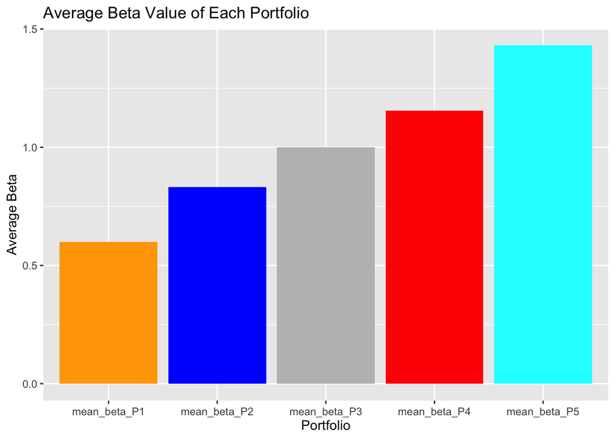

##### 3.1.2 Daily Beta Box Plot

Below we can inspect the box plot for the daily betas of each individual portfolios. Obviously, the beta values increase in an ascending order. Portfolio 5 possese the highest variance in beta values which then lowers descendingly. Interstingly the box plot indicates that the beta values of portfolio 1 have larger outliers then portfolio 2.

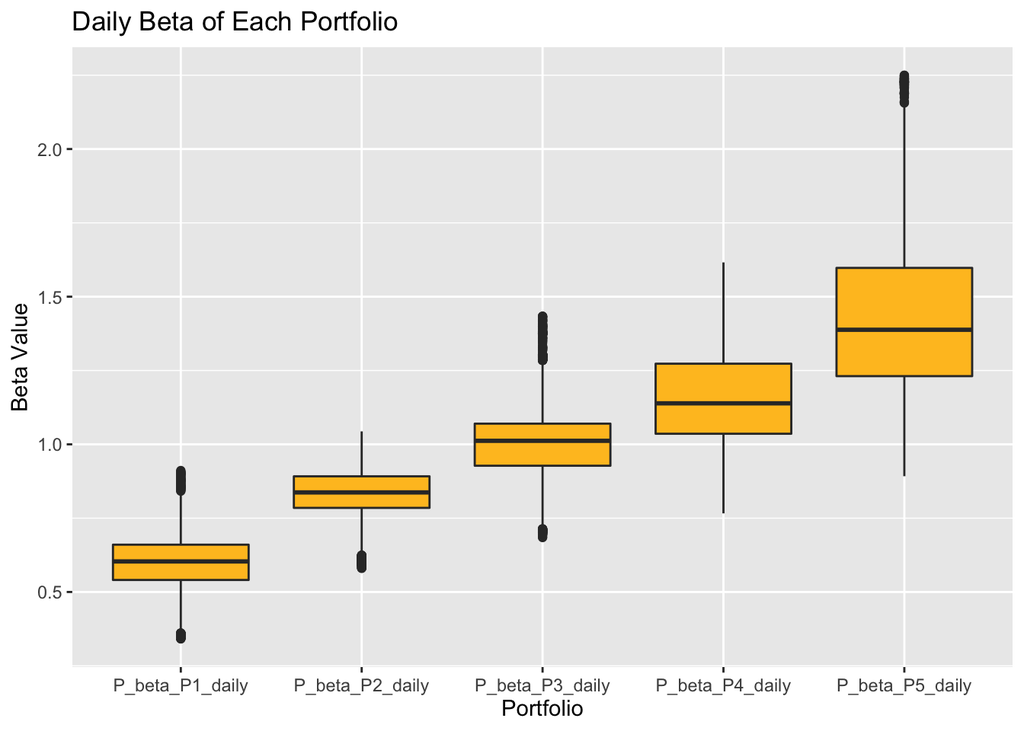

##### 3.1.3 Time Series of Beta Values

Lastly, we take a view how the beta values behave over time. The line chart outlines this behaviour.We can see how portfolios with higher betas possess higher variance in its movement. Furthermore, the chart suggest repeating patterns of consolidation where the quintile values move closer, followed by a period of expansion where the quintile values drift apart.

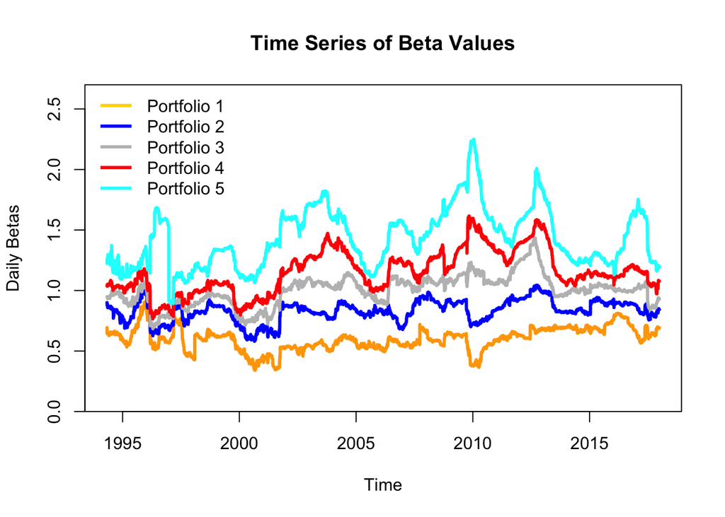

##### 3.2 Analysis of Daily Returns

##### 3.2.1 Daily Returns Boxplot

Next we shall have a closer look at the daily returns. For illustration we plot the daily returns in in a box plot. As we can see, the variance is lowest for portfolio 1 and increases proportionally with each portfolio that possess a higher beta. Except for the outliers of portfolio 2, this is excepted and in compliance with the CAPM.

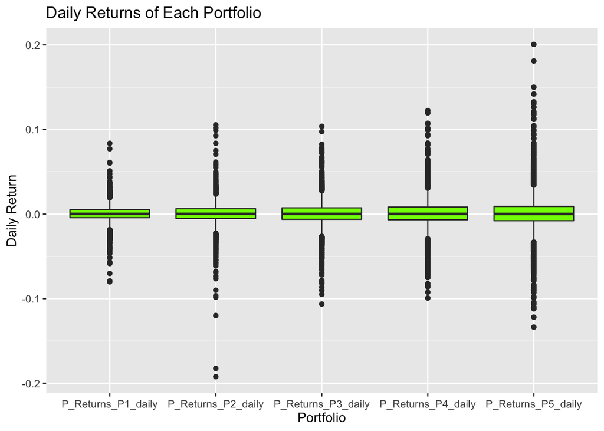

##### 3.2.2 Mean Returns

As our second step, we analyse the mean returns. The bar chart presents us the mean returns of each portfolio. It shows, that the returns increase for each portfolio with higher beta like the CAPM would predict. However, surprsingly portfolio 4 gives us the highest returns, while portfolio has even lower returns than portfolio 3.

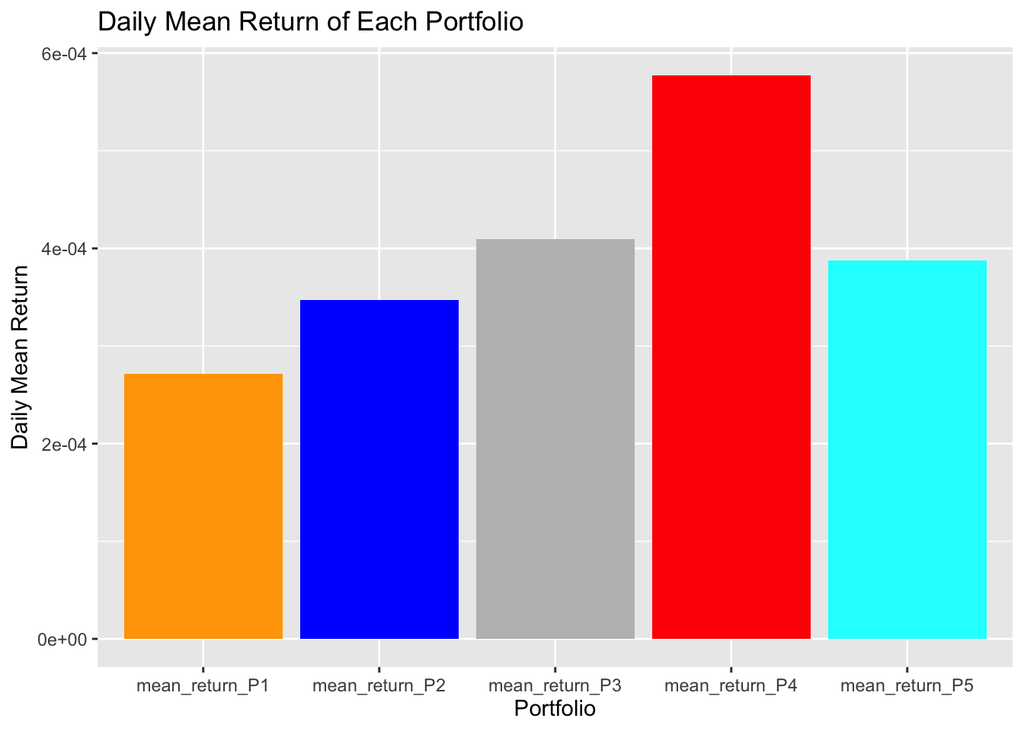

##### 3.2.3 Standard Deviation of Returns

The following bar chart depicts the standard deviation of the portfolios returns. Here again the volatility rises with increasing beta, in accordance to the CAPM.

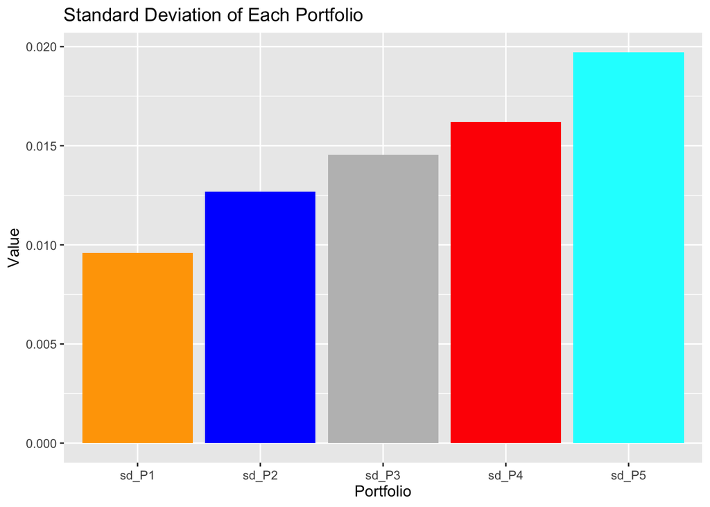

##### 3.2.4 Summary table

Finally, we can inspect the mean daily returns as well as the mean standard deviation of each portfolio.  
The following table consolidates our findings:

```
##                           Portfolio1   Portfolio2   Portfolio3  Portfolio4
## Mean Daily Return       0.0002712605 0.0003467593 0.0004093706 0.000577349
## Mean Standard Deviation 0.0095879325 0.0126849545 0.0145477016 0.016199918
##                           Portfolio5
## Mean Daily Return       0.0003873376
## Mean Standard Deviation 0.0197180085
```

#### 3.3 Analysis of Cumulative Returns

##### 3.3.1 Cumulative Returns of the Porfolios

We come to our final analysis where we examine the cumulative returns of the portfolios. As expected from the highest mean returns Portfolio 4 has gives the highest cumulative return as well. It’s value has multiplied by 15.74. In contrast, the weakest return is delivered by Portfolio 5. The value of Portfolio 5 has only multiplied by 3.3, close to a fifth of portfolio 4. The other portfolios can be sorted by their beta value; the higher the beta, the higher the cumulative return. However, the chart further suggests that low beta portfolios perform better during market corrections. In other words, higher beta portolios react stronger to negative market movements. Even portfolio 5, although providing the lowest cumulative return, reacts stronger than portfolio 1 and 2, but still less than portfolio 3 and 4.

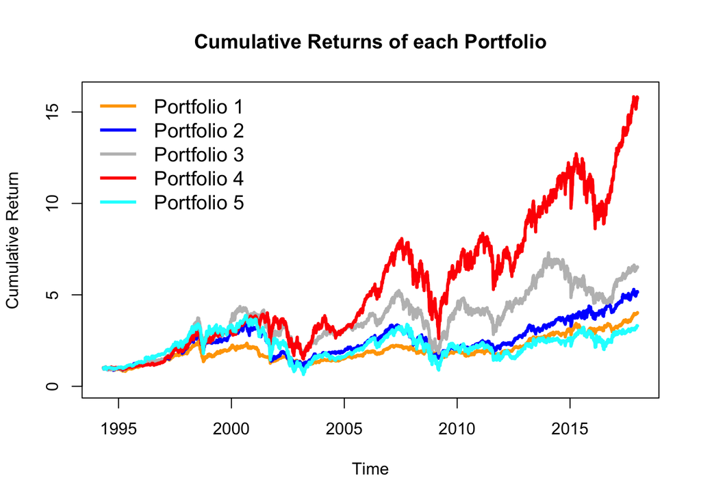

##### 3.3.2 SMI and 1YR Swiss Bond Return

We now introduce our two portfolios for performance comparison. We use the SMI from which the portfolios are built from, and the 1 Year Swiss Government Bond. Below we can see their cumulative return. As expected the 1YR Swiss Bond delivers a very small cumulative return, as it is seen as a riskless asset and therefore caputures no significant risk premium. The SMI follows a pattern of constant rise and fall inside a sideways channel from which it never break out from since the end of the 1990s.

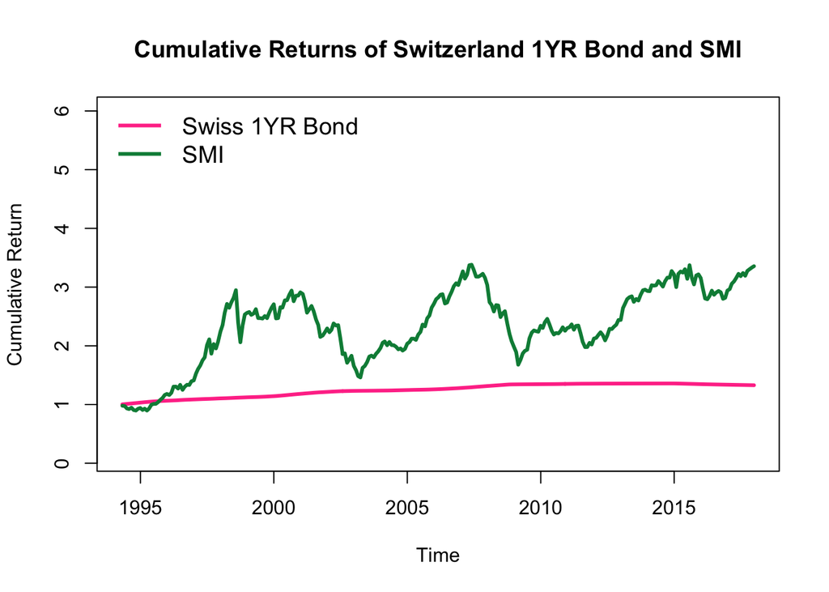

##### 3.3.3 Complete Comparison

We now compare the cumulative returns between each beta-based portfolio, SMI ETF, as well as the 1Year Swiss Government Bonds. The line chart indicates that porfolio 5 provides the lowest cumulative return for all equity based porftolios. The cumulative return even sinks below that of the 1YR Swiss Gov Bond twice; in the year 2003 and 2009. This heavily contradicts the CAPM, as the highest beta porftolio should earn the highest risk premium. All other beta sorted portfolio seem to outperform both the SMI and the 1YR Swiss Gov Bond.

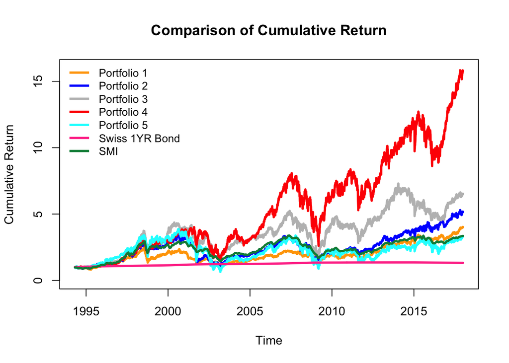

##### 3.3.4 Comparison of Yearly Geometric Return

Our findings are further consolidated in this bar chart. As we can see the average return of 5.33% per year for portfolio 5 is lower than the average return of 5.41% for the SMI . Other than that, portfilio 4 possesses the highest yearly return with 12.73% followed by the other beta sorted portfolio 3 (8.49%) , portfolio 2 (7.38%), and portfolio 1 (6.23%) which all outperform the SMI. Moreover, even though portfolio 3 has a average beta value close to 1 it still outperforms the SMI by a significant margin.

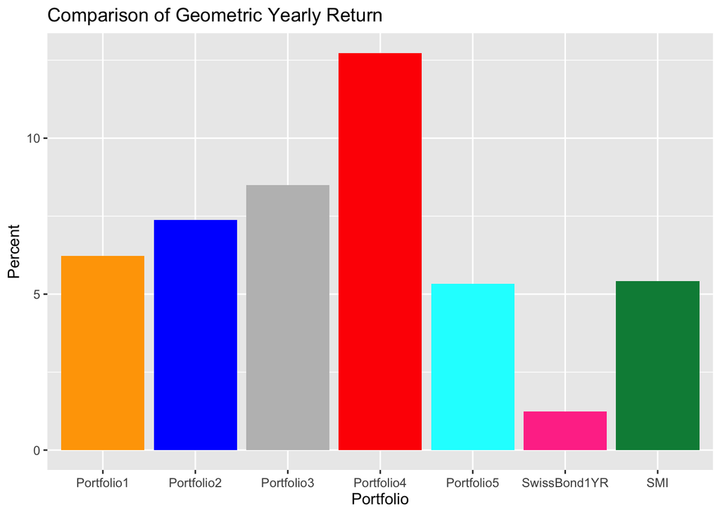

### 4. Conclusion

We see that the highest beta does not promise the highest return. On the contrary, the portfolio containing the stocks with the highest beta values performed even poorer than the benchmark the SMI. The portfolio containing the fourth quintile of highest beta values, delivered the highest return by a large margin instead. Furthermore, we see that portfolio 3 with its average beta value of 1 has outperformed the SMI as well. As the SMI is weighted according to market capitalization and contain roughly 20 stocks, it may not be as diversified as needed. Thus, its beta value may differ that from a true market portfolio and could indicate that the SMI fails to represent a market portfolio in compliance with the CAPM. Another caevat is that we didn’t include transaction costs. Nevertheless, the results are startling. As a next step, larger stock markets from other countries should be analysed to see if these findings can be reinforced.